# QR Decomposition

## Packages

```julia
using LinearAlgebra
using CSV, DataFrames, RCall
using LaTeXStrings, Plots
```

```
Precompiling packages...
   1988.6 ms  ✓ QuartoNotebookWorkerRCallExt (serial)
  1 dependency successfully precompiled in 2 seconds
```

## QR decomposition

Given $\mathbf{A} \in \mathbb{R}^{n \times p}$, QR decomposition factorizes $\mathbf{A}$ as $\mathbf{A} = \mathbf{Q} \mathbf{R}$.

## Gram-Schmidt Algorithm

**Input**: Vectors $\mathbf{a}_1, \ldots, \mathbf{a}_k \in \mathbb{R}^n$.

**Output**: The *Gram-Schmidt algorithm* generates a sequence of orthonormal vectors $\mathbf{q}_1, \mathbf{q}_2, \ldots$.

- For $i=1,\ldots,k$:
  1. Orthogonalization: $\tilde{\mathbf{q}}_i = \mathbf{a}_i - [(\mathbf{q}_1' \mathbf{a}_i) \mathbf{q}_1 + \cdots + (\mathbf{q}_{i-1}' \mathbf{a}_i) \mathbf{q}_{i-1}]$.
  2. Test for linear independence: if $\tilde{\mathbf{q}}_i = \mathbf{0}$, quit.
  3. Normalization: $\mathbf{q}_i = \tilde{\mathbf{q}}_i / \|\tilde{\mathbf{q}}_i\|$.
- If G-S does not stop early (in step 2), $\mathbf{a}_1, \ldots, \mathbf{a}_k$ are linearly independent.
- If G-S stops early in iteration $i=j$, then $\mathbf{a}_j$ is a linear combination of $\mathbf{a}_1, \ldots, \mathbf{a}_{j-1}$ and $\mathbf{a}_1, \ldots, \mathbf{a}_{j-1}$ are linearly independent.

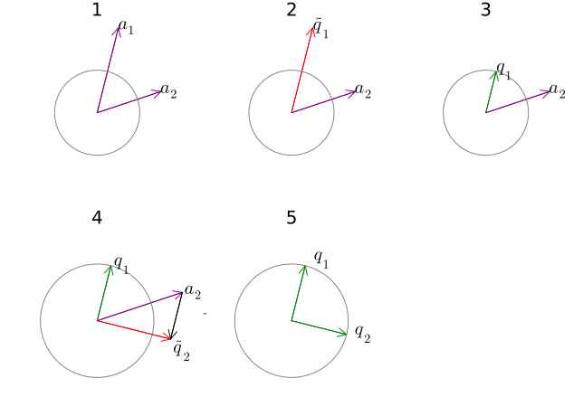

```julia
# Inputs
a1 = [0.5, 2]
a2 = [1.5, 0.5]

p1 = plot([0 0; a1[1] a2[1]], [0 0; a1[2] a2[2]],
  arrow = true, color = :purple, axis = ([], false), legend = :none,
  xlims = (-2, 2), ylims = (-2, 2),
  annotations = [
    (a1[1] + 0.2, a1[2], L"a_1"),
    (a2[1] + 0.2, a2[2], L"a_2")
  ],
  framestyle = :origin,
  aspect_ratio = :equal,
  title = "1"
)
t = 0:0.01:2π
plot!(p1, sin.(t), cos.(t), color = :gray)

# orthogonalizing a1
q̃1 = copy(a1)
p2 = plot([0 0; q̃1[1] a2[1]], [0 0; q̃1[2] a2[2]],
  arrow = true, color = [:red :purple], axis = ([], false), legend = :none,
  xlims = (-2, 2), ylims = (-2, 2),
  annotations = [
    (q̃1[1] + 0.2, q̃1[2], L"\tilde{q}_1"),
    (a2[1] + 0.2, a2[2], L"a_2")
  ],
  framestyle = :origin,
  aspect_ratio = :equal,
  title = "2"
)
t = 0:0.01:2π
plot!(p2, sin.(t), cos.(t), color = :gray)

# normalizing q̃1
q1 = q̃1 / norm(q̃1)
p3 = plot([0 0; q1[1] a2[1]], [0 0; q1[2] a2[2]],
  arrow = true, color = [:green :purple],
  axis = ([], false), legend = :none,
  xlims = (-2, 2), ylims = (-2, 2),
  annotations = [
    (q1[1] + 0.2, q1[2], L"q_1"),
    (a2[1] + 0.2, a2[2], L"a_2")
  ],
  framestyle = :origin,
  aspect_ratio = :equal,
  title = "3"
)
t = 0:0.01:2π
plot!(p3, sin.(t), cos.(t), color = :gray)

# orthogonalizing a2
q̃2 = a2 - dot(a2, q1) * q1
p4 = plot([0 0 0; q1[1] a2[1] q̃2[1]], [0 0 0; q1[2] a2[2] q̃2[2]],
  arrow = true, color = [:green :purple :red], axis = ([], false), legend = :none,
  xlims = (-1.5, 1.5), ylims = (-1.5, 1.5),
  annotations = [
    (q1[1] + 0.2, q1[2], L"q_1"),
    (a2[1] + 0.2, a2[2], L"a_2"),
    (q̃2[1] + 0.2, q̃2[2] - 0.2, L"\tilde{q}_2"),
    ((a2[1] + q̃2[1]) / 2 + 1.2, (a2[2] + q̃2[2]) / 2, L"-(q_1' a_2)q_1")
  ],
  framestyle = :origin,
  aspect_ratio = :equal,
  title = "4"
)
t = 0:0.01:2π
plot!(p4, sin.(t), cos.(t), color = :gray)
plot!(p4, [a2[1]; q̃2[1]], [a2[2]; q̃2[2]], arrow = true, color = :black)

# normalizing q̃2
q2 = q̃2 / norm(q̃2)
p5 = plot([0 0; q1[1] q2[1]], [0 0; q1[2] q2[2]],
  arrow = true, color = :green,
  axis = ([], false), legend = :none,
  xlims = (-1.5, 1.5), ylims = (-1.5, 1.5),
  annotations = [
    (q1[1] + 0.3, q1[2] + 0.1, L"q_1"),
    (q2[1] + 0.3, q2[2], L"q_2")
  ],
  framestyle = :origin,
  aspect_ratio = :equal,
  title = "5"
)
t = 0:0.01:2π
plot!(p5, sin.(t), cos.(t), color = :gray)

plot(p1, p2, p3, p4, p5)
```

**Note**

All circles shown here are unit circles with radius 1. The first three circles appear smaller to work around a “clipping” issue in the plotting engine.

```julia
# n = 5, k = 3
@show a1 = randn(5)
@show a2 = randn(5)
@show a3 = randn(5);
```

```
a1 = randn(5) = [0.23685422017234373, -1.0087534122873563, 0.17642361956991978, -0.154688375513604, -0.05538328181484032]
a2 = randn(5) = [-0.2104631549207379, -1.1824200068374213, -0.2707535827603134, -0.16256273974216195, -0.5383770058975711]
a3 = randn(5) = [-0.7886321027307643, 1.026758201417579, 0.22635150466775936, -0.49213864078543773, -1.249631181080849]
```

```julia
# for i = 1
# orthogonalization
@show q̃1 = copy(a1)
# test for linear independence
@show norm(q̃1) ≈ 0
# normalization
@show q1 = q̃1 / norm(q̃1);
```

```
q̃1 = copy(a1) = [0.23685422017234373, -1.0087534122873563, 0.17642361956991978, -0.154688375513604, -0.05538328181484032]
norm(q̃1) ≈ 0 = false
q1 = q̃1 / norm(q̃1) = [0.2226360181725102, -0.948198612911239, 0.16583302650908396, -0.14540253476110163, -0.05205866008049196]
```

```julia
# for i = 2
# orthogonalization
@show q̃2 = a2 - (q1'a2) * q1
# test for linear independence
@show norm(q̃2) ≈ 0
# normalization
@show q2 = q̃2 / norm(q̃2);
```

```
q̃2 = a2 - (q1' * a2) * q1 = [-0.45114975906069155, -0.15734461218593876, -0.450031798083923, -0.005371452311419167, -0.4820976032488002]
norm(q̃2) ≈ 0 = false
q2 = q̃2 / norm(q̃2) = [-0.5539567759519859, -0.19319995706395263, -0.5525840564815815, -0.006595487074644128, -0.5919569469479827]
```

```julia
# for i = 3
# orthogonalization
@show q̃3 = a3 - (q1'a3) * q1 - (q2'a3) * q2
# test for linear independence
@show norm(q̃3) ≈ 0
# Normalization
@show q3 = q̃3 / norm(q̃3);
```

```
q̃3 = (a3 - (q1' * a3) * q1) - (q2' * a3) * q2 = [-0.09715679930255056, 0.2677200915156421, 0.8612683180022298, -0.6282577371876686, -0.7934399966073402]
norm(q̃3) ≈ 0 = false
q3 = q̃3 / norm(q̃3) = [-0.07148615692690129, 0.19698343926475095, 0.6337051300459979, -0.462260299984569, -0.5837983189722403]
```

```julia
# test for orthonormality of q1, q2, q3
@show norm(q1), norm(q2), norm(q3)
@show q1'q2
@show q1'q3
@show q2'q3;
```

```
(norm(q1), norm(q2), norm(q3)) = (1.0, 1.0, 0.9999999999999999)
q1' * q2 = 2.4203152163668796e-16
q1' * q3 = -1.2856358646856095e-16
q2' * q3 = -9.185840984983169e-18
```

## Complexity

Computational complexity of G-S algorithm:

- Step 1 of iteration $i$ requires (1) $i-1$ inner products, $\mathbf{q}_1' \mathbf{a}_i, \ldots, \mathbf{q}_{i-1}' \mathbf{a}_i$, which costs $(i-1)(2n-1)$ flops, and (2) $2n(i-1)$ flops to compute $\tilde{\mathbf{q}}_i$.
- Step 2 of iteration $i$ requires less than $n$ flops.
- Step 3 of iteration $i$ requires $3n$ flops to normalize $\|\tilde{\mathbf{q}}_i\|$.
- Assuming no early termination, total computational cost of the GS algorithm to orthonormalize a set of $k$ vectors in $\mathbb{R}^n$ is:
  $$\sum_{i=1}^k [(4n-1) (i - 1) + 3n] = (4n - 1) \frac{k(k-1)}{2} + 3nk \approx 2nk^2 = O(nk^2),$$

using $\sum_{i=1}^k (i - 1) = k(k-1)/2$.

## GS Algorithm and QR Factorization

The operations in GS can be compactly expressed as

$$\mathbf{A} = \mathbf{Q} \mathbf{R},$$

where $\mathbf{A} = (\mathbf{a}_1 \, \cdots \, \mathbf{a}_k) \in \mathbb{R}^{n \times k}$, $\mathbf{Q} = (\mathbf{q}_1 \, \cdots \, \mathbf{q}_k) \in \mathbb{R}^{n \times k}$ satisfying $\mathbf{Q}'\mathbf{Q} = \mathbf{I}_k$ ($\mathbf{Q}$ has orthonormal columns), and $\mathbf{R} \in \mathbb{R}^{k \times k}$ is an upper triangular matrix with positive diagonal elements.

What are the entries in $\mathbf{R}$? In the $i$-th iteration of the Gram-Schmidt algorithm

$$\begin{eqnarray*}
\text{Orthogonalization step: } & & \tilde{\mathbf{q}}_i = \mathbf{a}_i - (\mathbf{q}_1' \mathbf{a}_i) \mathbf{q}_1 - \cdots - (\mathbf{q}_{i-1}' \mathbf{a}_i) \mathbf{q}_{i-1} \\
\text{Normalization step: } & & \mathbf{q}_i = \tilde{\mathbf{q}}_i / \|\tilde{\mathbf{q}}_i\|.
\end{eqnarray*}$$

Therefore,
$$\mathbf{a}_i = (\mathbf{q}_1' \mathbf{a}_i) \mathbf{q}_1 + \cdots + (\mathbf{q}_{i-1}' \mathbf{a}_i) \mathbf{q}_{i-1} + \|\tilde{\mathbf{q}}_i\| \mathbf{q}_i.$$

This tells us $R_{ij} = \mathbf{q}_i' \mathbf{a}_j$ for $i < j$ and $R_{ii} = \|\tilde{\mathbf{q}}_i\|$.

Thus overall Gram-Schmidt algorithm performs
$$\mathbf{A} = \begin{pmatrix} | & | & & | & | \\ \mathbf{a}_1 & \mathbf{a}_2 & \cdots & \mathbf{a}_{k-1} & \mathbf{a}_k \\ | & | & & | & | \end{pmatrix} = \begin{pmatrix} | & | & & | & | \\ \mathbf{q}_1 & \mathbf{q}_2 & \cdots & \mathbf{q}_{k-1} & \mathbf{q}_k \\ | & | & & | & | \end{pmatrix} \begin{pmatrix}
\|\tilde{\mathbf{q}}_1\| & \mathbf{q}_1'\mathbf{a}_2 & \cdots & \mathbf{q}_1' \mathbf{a}_{k-1} & \mathbf{q}_1' \mathbf{a}_k \\
& \|\tilde{\mathbf{q}}_2\| & \cdots & \mathbf{q}_2' \mathbf{a}_{k-1} & \mathbf{q}_2' \mathbf{a}_k \\
& & \ddots & \vdots & \vdots \\
& & & \|\tilde{\mathbf{q}}_{k-1}\| & \mathbf{q}_{k-1}' \mathbf{a}_k \\
& & & & \|\tilde{\mathbf{q}}_k\|
\end{pmatrix} = \mathbf{Q} \mathbf{R}.$$

**Warning**

The Gram-Schmidt algorithm is **numerically unstable**. The specific issue that arises is that the basis vectors $\mathbf{q}_{k}$ may lose their orthogonality. The [*modified* Gram-Schmidt](https://en.wikipedia.org/wiki/Gram%E2%80%93Schmidt_process#Numerical_stability) is preferred. In your homework you will implement QR via Householder reflections, which is more stable and efficient (the basis vectors are computed implicitly).

## Solving linear systems

Now look at solving linear systems (full column rank), assuming we already have $\mathbf{Q}$ and $\mathbf{R}$:

$$\mathbf{A} \mathbf{x} = \mathbf{b} \equiv \mathbf{Q} \mathbf{R} \mathbf{x} = \mathbf{b} \implies \text{Solve}~\mathbf{R} \mathbf{x} = \mathbf{Q}^\top \mathbf{y}$$

- Form RHS: $2np$ flops (since $\mathbf{Q}$ is $n \times p$)
- Solve with backward substitution: $p^{2}$ flops
- Total: $2np + p^{2}$

## Solving least squares

Least squares problem $\min_{\beta}~\frac{1}{2} \|\mathbf{y} - \mathbf{X}\beta\|_{2}^{2}$ has the same complexity:

- **Why?** Use properties of orthonormal matrices…
- Reduction to $\min_{\beta}~\frac{1}{2}\|\mathbf{Q}^\top \mathbf{y} - \mathbf{R}\beta\|_{2}^{2}$.
- **Fit $\beta$** (QR + solve): $2(n-1)p^{2} - \frac{2}{3} p^{3} + 2np$
- **Standard errors for estimates**: Requires inverting $\mathbf{X}^\top \mathbf{X}$ (one of a few cases where it is acceptable!)

We can be far more clever about inverting the matrix. View the problem of computing $(\mathbf{X}^\top \mathbf{X})^{-1}$ as:

$$\text{Solve}~\mathbf{X}^{\top}\mathbf{X} \mathbf{\Sigma} = \mathbf{I} \quad \equiv \quad \mathbf{R}^\top \mathbf{R} \mathbf{\Sigma} = \mathbf{I};$$

that is, we solve two triangular systems for the matrix-valued variable $\mathbf{\Sigma}$.

**Note**

Note that $\operatorname{Var}(\hat{\beta})$ depends on $\mathbf{X}$ in linear regression, but the explicit form for the standard errors depends on whatever assumptions we are willing to make about the random component (e.g. normal errors).

## Example: Longley data

```julia
column_labels = ["Employed", "Price", "GNP", "Jobless", "Military", "PopSize", "Year"]
longley = CSV.read(joinpath("assets", "longley.txt"), DataFrame;
  header = column_labels,
  delim = ' ',
  ignorerepeated = true
)
```

16×7 DataFrame

| Row | Employed Int64 | Price Float64 | GNP Int64 | Jobless Int64 | Military Int64 | PopSize Int64 | Year Int64 |
| --- | --- | --- | --- | --- | --- | --- | --- |
| 1 | 60323 | 83.0 | 234289 | 2356 | 1590 | 107608 | 1947 |
| 2 | 61122 | 88.5 | 259426 | 2325 | 1456 | 108632 | 1948 |
| 3 | 60171 | 88.2 | 258054 | 3682 | 1616 | 109773 | 1949 |
| 4 | 61187 | 89.5 | 284599 | 3351 | 1650 | 110929 | 1950 |
| 5 | 63221 | 96.2 | 328975 | 2099 | 3099 | 112075 | 1951 |
| 6 | 63639 | 98.1 | 346999 | 1932 | 3594 | 113270 | 1952 |
| 7 | 64989 | 99.0 | 365385 | 1870 | 3547 | 115094 | 1953 |
| 8 | 63761 | 100.0 | 363112 | 3578 | 3350 | 116219 | 1954 |
| 9 | 66019 | 101.2 | 397469 | 2904 | 3048 | 117388 | 1955 |
| 10 | 67857 | 104.6 | 419180 | 2822 | 2857 | 118734 | 1956 |
| 11 | 68169 | 108.4 | 442769 | 2936 | 2798 | 120445 | 1957 |
| 12 | 66513 | 110.8 | 444546 | 4681 | 2637 | 121950 | 1958 |
| 13 | 68655 | 112.6 | 482704 | 3813 | 2552 | 123366 | 1959 |
| 14 | 69564 | 114.2 | 502601 | 3931 | 2514 | 125368 | 1960 |
| 15 | 69331 | 115.7 | 518173 | 4806 | 2572 | 127852 | 1961 |
| 16 | 70551 | 116.9 | 554894 | 4007 | 2827 | 130081 | 1962 |

```julia
y = longley.Employed
X = [ones(length(y)) Matrix(select(longley, Not(:Employed)))]
```

```
16×7 Matrix{Float64}:
 1.0   83.0  234289.0  2356.0  1590.0  107608.0  1947.0
 1.0   88.5  259426.0  2325.0  1456.0  108632.0  1948.0
 1.0   88.2  258054.0  3682.0  1616.0  109773.0  1949.0
 1.0   89.5  284599.0  3351.0  1650.0  110929.0  1950.0
 1.0   96.2  328975.0  2099.0  3099.0  112075.0  1951.0
 1.0   98.1  346999.0  1932.0  3594.0  113270.0  1952.0
 1.0   99.0  365385.0  1870.0  3547.0  115094.0  1953.0
 1.0  100.0  363112.0  3578.0  3350.0  116219.0  1954.0
 1.0  101.2  397469.0  2904.0  3048.0  117388.0  1955.0
 1.0  104.6  419180.0  2822.0  2857.0  118734.0  1956.0
 1.0  108.4  442769.0  2936.0  2798.0  120445.0  1957.0
 1.0  110.8  444546.0  4681.0  2637.0  121950.0  1958.0
 1.0  112.6  482704.0  3813.0  2552.0  123366.0  1959.0
 1.0  114.2  502601.0  3931.0  2514.0  125368.0  1960.0
 1.0  115.7  518173.0  4806.0  2572.0  127852.0  1961.0
 1.0  116.9  554894.0  4007.0  2827.0  130081.0  1962.0
```

Solve for coefficients:

```julia
qrX = qr(X)
β = qrX \ y
```

```
7-element Vector{Float64}:
   -3.48225863459695e6
   15.061872271782592
   -0.03581917929265219
   -2.020229803816748
   -1.0332268671733362
   -0.051104105653733134
 1829.1514646141297
```

Get standard errors:

```julia
r = y - X*β # residuals
s² = r'r / (length(y) - length(β)) # correction: n - p
tmp = UpperTriangular(qrX.R)' \ (1.0 * I(length(β))) # trisolve 1
Σβ = UpperTriangular(qrX.R) \ tmp # trisolve 2
sqrt.(s² * diag(Σβ)) # variances on diagonal
```

```
7-element Vector{Float64}:
 890420.3836067042
     84.914925774739
      0.033491007772225766
      0.48839968165124664
      0.21427416316149153
      0.22607320006921489
    455.47849914186986
```

Back in R:

```r
# Regress Employed on all other variables; add intercept
fit.longley <- lm(Employed ~ . + 1, data = $longley)
```

[output not shown]

```r
# Fitted β
coef(fit.longley)
```

```
7-element Vector{Float64}:
   -3.482258634595826e6
   15.061872271374863
   -0.0358191792925914
   -2.0202298038168283
   -1.0332268671735907
   -0.05110410565357941
 1829.1514646135556
```

```r
# Can see standard errors here
print(coef(summary(fit.longley)));
```

```
                 Estimate   Std. Error    t value     Pr(>|t|)
(Intercept) -3.482259e+06 8.904204e+05 -3.9108029 0.0035604037
Price        1.506187e+01 8.491493e+01  0.1773760 0.8631408328
GNP         -3.581918e-02 3.349101e-02 -1.0695163 0.3126810611
Jobless     -2.020230e+00 4.883997e-01 -4.1364274 0.0025350917
Military    -1.033227e+00 2.142742e-01 -4.8219853 0.0009443668
PopSize     -5.110411e-02 2.260732e-01 -0.2260511 0.8262117958
Year         1.829151e+03 4.554785e+02  4.0158898 0.0030368033
```

```
7×4 Matrix{Float64}:
   -3.48226e6    8.9042e5  -3.9108    0.0035604
   15.0619      84.9149     0.177376  0.863141
   -0.0358192    0.033491  -1.06952   0.312681
   -2.02023      0.4884    -4.13643   0.00253509
   -1.03323      0.214274  -4.82199   0.000944367
   -0.0511041    0.226073  -0.226051  0.826212
 1829.15       455.478      4.01589   0.0030368
```